# Problem Set 2 Write Up

Jackson Dixon

2026-10-21

**GitHub repo:** https://github.com/Noskcaj8/ec422_PS2_Jackson.git

## Data

This data comes from the Federal Reserve Economic Data (FRED) database, accessed through the ‘tidyquant’ package. It includes monthly employment rates for the United States, California, Oregon, Texas, and New York, from 1976 through 2026.

```r
library(tidyquant)
library(knitr)
library(tidyverse)

unemp_raw <- read_rds("data/unemp_raw.rds")
head(unemp_raw)
```

```
# A tibble: 6 × 3
  symbol date       price
  <chr>  <date>     <dbl>
1 UNRATE 1976-01-01   7.9
2 UNRATE 1976-02-01   7.7
3 UNRATE 1976-03-01   7.6
4 UNRATE 1976-04-01   7.7
5 UNRATE 1976-05-01   7.4
6 UNRATE 1976-06-01   7.6
```

```r
#| message: false
source("ps2_script_Jackson.R")
```

## Wrangling

The following tables summarize key patterns in the unemployment data.

Mean, minimum, and maximum unemployment rate by region, full sample

| region | mean_rate | min_rate | max_rate |
| --- | --- | --- | --- |
| California | 7.071100 | 3.8 | 16.1 |
| New York | 6.343186 | 3.8 | 16.7 |
| Oregon | 6.658785 | 3.4 | 13.7 |
| Texas | 5.844663 | 3.4 | 12.8 |
| United States | 6.046305 | 3.4 | 14.8 |

Mean, minimum, and maximum unemployment rate by region, 2015-present

| region | mean_rate | min_rate | max_rate |
| --- | --- | --- | --- |
| California | 5.627660 | 3.8 | 16.1 |
| New York | 5.095035 | 3.8 | 16.7 |
| Oregon | 4.751064 | 3.4 | 13.7 |
| Texas | 4.580142 | 3.4 | 12.8 |
| United States | 4.619858 | 3.4 | 14.8 |

| symbol | date | unemployment_rate | region | unemployment_rate_change |
| --- | --- | --- | --- | --- |
| TXUR | 2009-05-01 | 7.6 | Texas | 1.1 |
| ORUR | 2008-12-01 | 8.9 | Oregon | 0.7 |
| ORUR | 2008-11-01 | 8.2 | Oregon | 0.7 |
| ORUR | 2009-01-01 | 9.6 | Oregon | 0.7 |
| ORUR | 1980-03-01 | 7.4 | Oregon | 0.6 |
| UNRATE | 1980-04-01 | 6.9 | United States | 0.6 |

| symbol | date | unemployment_rate | region | unemployment_rate_change |
| --- | --- | --- | --- | --- |
| UNRATE | 1983-07-01 | 9.4 | United States | -0.7 |
| NYUR | 2021-09-01 | 6.2 | New York | -0.6 |
| ORUR | 1977-05-01 | 7.8 | Oregon | -0.5 |
| CAUR | 2021-07-01 | 7.4 | California | -0.5 |
| CAUR | 2021-09-01 | 6.5 | California | -0.5 |
| NYUR | 2021-07-01 | 7.0 | New York | -0.5 |
| UNRATE | 2010-12-01 | 9.3 | United States | -0.5 |
| UNRATE | 2014-04-01 | 6.2 | United States | -0.5 |
| UNRATE | 2021-07-01 | 5.4 | United States | -0.5 |

## Visualization

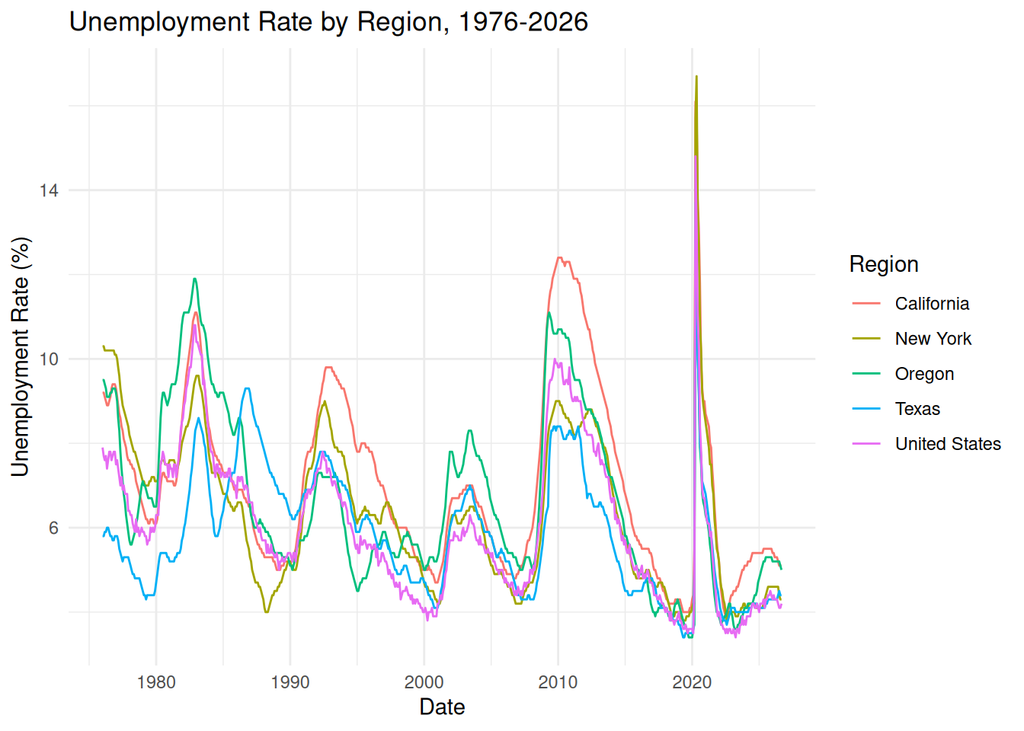

Unemployment rate by region over time

```r
ggplot(unemp, aes(x = date, y = unemployment_rate, color = region)) +
  geom_line() +
  labs(
    title = "Unemployment Rate by Region, 1976-2026",
    x = "Date",
    y = "Unemployment Rate (%)",
    color = "Region"
  ) +
  theme_minimal()
```

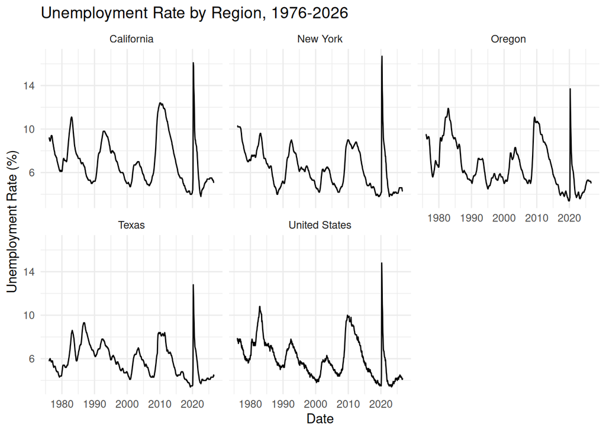

Unemployment rate by region, individual panels

```r
ggplot(unemp, aes(x = date, y = unemployment_rate)) +
  geom_line() +
  facet_wrap(~ region) +
  labs(
    title = "Unemployment Rate by Region, 1976-2026",
    x = "Date",
    y = "Unemployment Rate (%)"
  ) +
  theme_minimal()
```

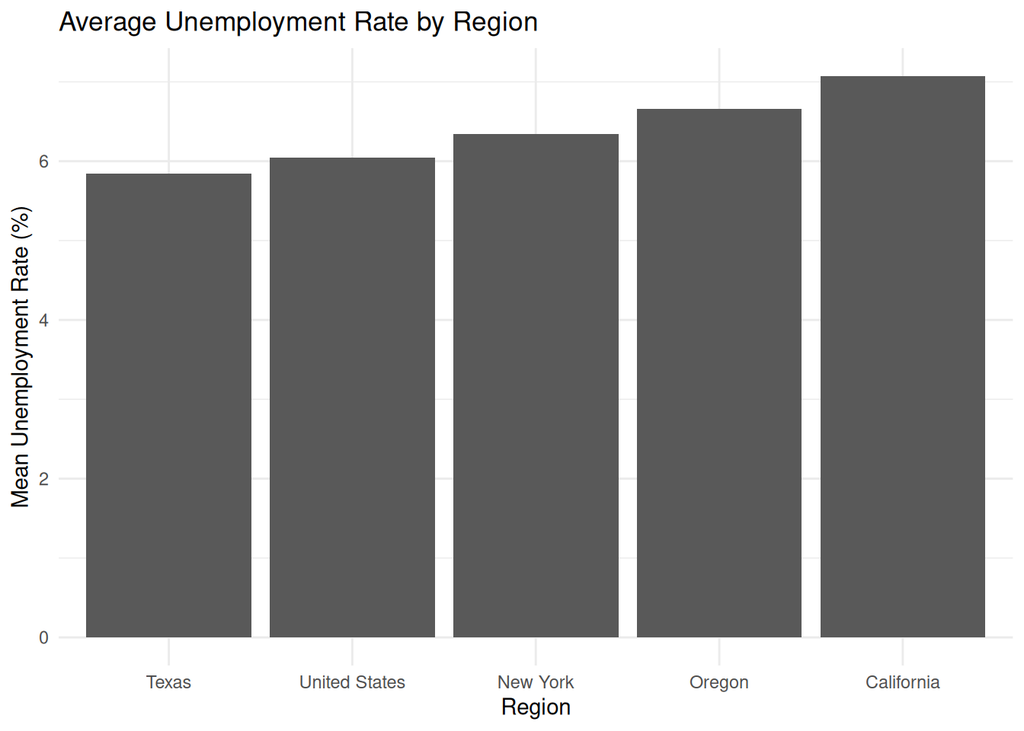

Average unemployment rate by region, full sample

```r
ggplot(unemp_summary, aes(x = fct_reorder(region, mean_rate), y = mean_rate)) +
  geom_col() +
  labs(
    title = "Average Unemployment Rate by Region",
    x = "Region",
    y = "Mean Unemployment Rate (%)"
  ) +
  theme_minimal()
```

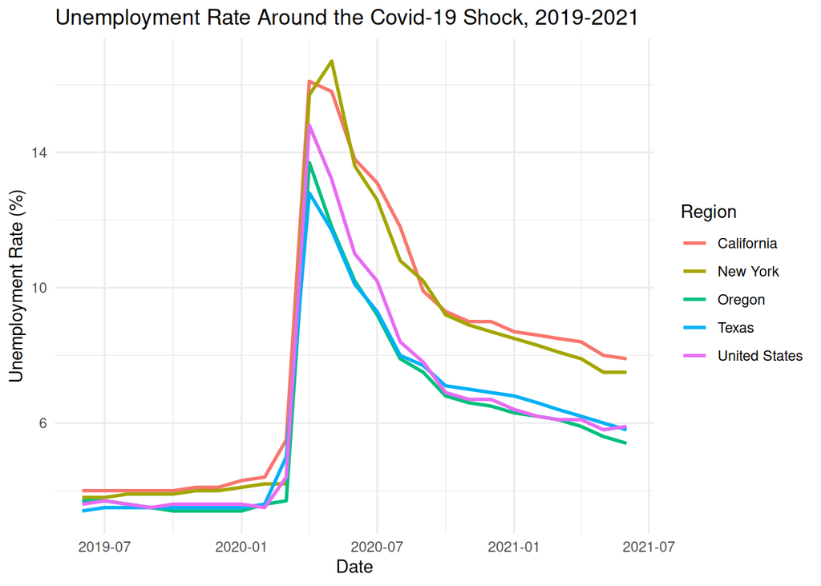

Unemployment rate around the Covid-19 shock

```r
unemp |>
  filter(date >= as.Date("2019-06-01") & date <= as.Date("2021-06-01")) |>
  ggplot(aes(x = date, y = unemployment_rate, color = region)) +
  geom_line(linewidth = 1) +
  labs(
    title = "Unemployment Rate Around the Covid-19 Shock, 2019-2021",
    x = "Date",
    y = "Unemployment Rate (%)",
    color = "Region"
  ) +
  theme_minimal()
```

## Reflection

This was a very tedious process that I wasn’t expecting, but was a good experience for me in terms of learning how to use the software and where I need to go for help. As you know I have had trouble getting R to work properly for me as my iPad didn’t do the job, and the computer I am borrowing is extremely old (13 years!). I found some very helpful people at the Data Science tutoring center in the library to help me fix my computer and get it running R so I could actually complete this assignment and I’m very grateful for them. Once I had it working, typing each piece of code was long and a little annoying but it helped me get some type of understanding of what each piece of code was doing and how it worked. I did end up running into another software issue with Quarto but the posit cloud was able to replace that (thanks to Claude for figuring that out). But overall this problem set taught me how useful R is as a software and all the amazing things it can do with data if you know how to work it.